# Risk Factor Analysis

## Outcome Variable

**Outcome Variable:** whz

## Predictor Variables

**Intervention Variable:** cleanck

**Adjustment Set:**

unadjusted

## Stratifying Variables

The analysis was stratified on these variable(s):

- agecat
- studyid
- country

## Data Summary

| agecat | studyid | country | cleanck | n_cell | n |
| --- | --- | --- | --- | --- | --- |
| Birth | CMC-V-BCS-2002 | INDIA | 1 | 37 | 86 |
| Birth | CMC-V-BCS-2002 | INDIA | 0 | 49 | 86 |
| Birth | GMS-Nepal | NEPAL | 1 | 9 | 570 |
| Birth | GMS-Nepal | NEPAL | 0 | 561 | 570 |
| Birth | IRC | INDIA | 1 | 198 | 337 |
| Birth | IRC | INDIA | 0 | 139 | 337 |
| Birth | MAL-ED | PERU | 1 | 1 | 2 |
| Birth | MAL-ED | PERU | 0 | 1 | 2 |
| Birth | NIH-Crypto | BANGLADESH | 1 | 336 | 543 |
| Birth | NIH-Crypto | BANGLADESH | 0 | 207 | 543 |
| Birth | PROVIDE | BANGLADESH | 1 | 433 | 532 |
| Birth | PROVIDE | BANGLADESH | 0 | 99 | 532 |
| 6 months | CMC-V-BCS-2002 | INDIA | 1 | 162 | 368 |
| 6 months | CMC-V-BCS-2002 | INDIA | 0 | 206 | 368 |
| 6 months | GMS-Nepal | NEPAL | 1 | 8 | 505 |
| 6 months | GMS-Nepal | NEPAL | 0 | 497 | 505 |
| 6 months | IRC | INDIA | 1 | 229 | 398 |
| 6 months | IRC | INDIA | 0 | 169 | 398 |
| 6 months | MAL-ED | SOUTH AFRICA | 1 | 1 | 1 |
| 6 months | MAL-ED | SOUTH AFRICA | 0 | 0 | 1 |
| 6 months | NIH-Crypto | BANGLADESH | 1 | 329 | 545 |
| 6 months | NIH-Crypto | BANGLADESH | 0 | 216 | 545 |
| 6 months | PROVIDE | BANGLADESH | 1 | 497 | 603 |
| 6 months | PROVIDE | BANGLADESH | 0 | 106 | 603 |
| 24 months | CMC-V-BCS-2002 | INDIA | 1 | 163 | 372 |
| 24 months | CMC-V-BCS-2002 | INDIA | 0 | 209 | 372 |
| 24 months | GMS-Nepal | NEPAL | 1 | 5 | 434 |
| 24 months | GMS-Nepal | NEPAL | 0 | 429 | 434 |
| 24 months | IRC | INDIA | 1 | 231 | 400 |
| 24 months | IRC | INDIA | 0 | 169 | 400 |
| 24 months | MAL-ED | SOUTH AFRICA | 1 | 1 | 1 |
| 24 months | MAL-ED | SOUTH AFRICA | 0 | 0 | 1 |
| 24 months | NIH-Crypto | BANGLADESH | 1 | 199 | 410 |
| 24 months | NIH-Crypto | BANGLADESH | 0 | 211 | 410 |
| 24 months | PROVIDE | BANGLADESH | 1 | 480 | 579 |
| 24 months | PROVIDE | BANGLADESH | 0 | 99 | 579 |

The following strata were considered:

- agecat: 24 months, studyid: CMC-V-BCS-2002, country: INDIA
- agecat: 24 months, studyid: GMS-Nepal, country: NEPAL
- agecat: 24 months, studyid: IRC, country: INDIA
- agecat: 24 months, studyid: MAL-ED, country: SOUTH AFRICA
- agecat: 24 months, studyid: NIH-Crypto, country: BANGLADESH
- agecat: 24 months, studyid: PROVIDE, country: BANGLADESH
- agecat: 6 months, studyid: CMC-V-BCS-2002, country: INDIA
- agecat: 6 months, studyid: GMS-Nepal, country: NEPAL
- agecat: 6 months, studyid: IRC, country: INDIA
- agecat: 6 months, studyid: MAL-ED, country: SOUTH AFRICA
- agecat: 6 months, studyid: NIH-Crypto, country: BANGLADESH
- agecat: 6 months, studyid: PROVIDE, country: BANGLADESH
- agecat: Birth, studyid: CMC-V-BCS-2002, country: INDIA
- agecat: Birth, studyid: GMS-Nepal, country: NEPAL
- agecat: Birth, studyid: IRC, country: INDIA
- agecat: Birth, studyid: MAL-ED, country: PERU
- agecat: Birth, studyid: NIH-Crypto, country: BANGLADESH
- agecat: Birth, studyid: PROVIDE, country: BANGLADESH

### Dropped Strata

Some strata were dropped due to rare outcomes:

- agecat: Birth, studyid: MAL-ED, country: PERU
- agecat: 6 months, studyid: MAL-ED, country: SOUTH AFRICA
- agecat: 24 months, studyid: MAL-ED, country: SOUTH AFRICA

## Methods Detail

We’re interested in the causal parameters $E[Y_a]$ for all values of $a \in \mathcal{A}$. These parameters represent the mean outcome if, possibly contrary to fact, we intervened to set all units to have $A=a$. Under the randomization and positivity assumptions, these are identified by the statistical parameters $\psi_a=E_W[E_{Y|A,W}(Y|A=a,W)]$. In addition, we’re interested in the mean of $Y$, $E[Y]$ under no intervention (the observed mean). We will estimate these parameters by using SuperLearner to fit the relevant likelihood factors – $E_{Y|A,W}(Y|A=a,W)$ and $p(A=a|W)$, and then updating our likelihood fit using a joint TMLE.

For unadjusted analyses ($W=\{\}$), initial likelihoods were estimated using Lrnr_glm to estimate the simple $E(Y|A)$ and Lrnr_mean to estimate $p(A)$. For adjusted analyses, a small library containing Lrnr_glmnet, Lrnr_xgboost, and Lrnr_mean was used.

# Results Detail

## Results Plots

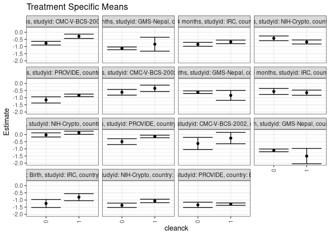

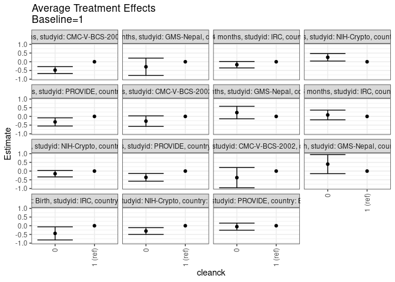

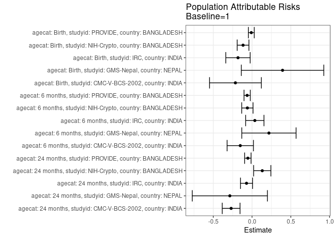

## Results Table

### Parameter: TSM

| agecat | studyid | country | intervention_level | baseline_level | estimate | ci_lower | ci_upper |
| --- | --- | --- | --- | --- | --- | --- | --- |
| Birth | CMC-V-BCS-2002 | INDIA | 1 | NA | -0.2500000 | -0.6457509 | 0.1457509 |
| Birth | CMC-V-BCS-2002 | INDIA | 0 | NA | -0.6270408 | -1.0538319 | -0.2002498 |
| Birth | GMS-Nepal | NEPAL | 1 | NA | -1.5077778 | -2.0451921 | -0.9703635 |
| Birth | GMS-Nepal | NEPAL | 0 | NA | -1.1081283 | -1.2024430 | -1.0138137 |
| Birth | IRC | INDIA | 1 | NA | -0.8046970 | -1.0534969 | -0.5558970 |
| Birth | IRC | INDIA | 0 | NA | -1.2444604 | -1.5275842 | -0.9613367 |
| Birth | NIH-Crypto | BANGLADESH | 1 | NA | -1.0680208 | -1.1887794 | -0.9472623 |
| Birth | NIH-Crypto | BANGLADESH | 0 | NA | -1.3725604 | -1.5263642 | -1.2187566 |
| Birth | PROVIDE | BANGLADESH | 1 | NA | -1.2886374 | -1.3729308 | -1.2043440 |
| Birth | PROVIDE | BANGLADESH | 0 | NA | -1.3414141 | -1.5268563 | -1.1559719 |
| 6 months | CMC-V-BCS-2002 | INDIA | 1 | NA | -0.3506173 | -0.5762645 | -0.1249700 |
| 6 months | CMC-V-BCS-2002 | INDIA | 0 | NA | -0.6222573 | -0.8239388 | -0.4205757 |
| 6 months | GMS-Nepal | NEPAL | 1 | NA | -0.8406250 | -1.1876486 | -0.4936014 |
| 6 months | GMS-Nepal | NEPAL | 0 | NA | -0.6195607 | -0.7114689 | -0.5276524 |
| 6 months | IRC | INDIA | 1 | NA | -0.6511281 | -0.8297153 | -0.4725409 |
| 6 months | IRC | INDIA | 0 | NA | -0.5669132 | -0.7796332 | -0.3541932 |
| 6 months | NIH-Crypto | BANGLADESH | 1 | NA | 0.1242401 | 0.0110550 | 0.2374252 |
| 6 months | NIH-Crypto | BANGLADESH | 0 | NA | -0.0275463 | -0.1719304 | 0.1168378 |
| 6 months | PROVIDE | BANGLADESH | 1 | NA | -0.1357478 | -0.2253996 | -0.0460960 |
| 6 months | PROVIDE | BANGLADESH | 0 | NA | -0.4960849 | -0.6980306 | -0.2941392 |
| 24 months | CMC-V-BCS-2002 | INDIA | 1 | NA | -0.2871677 | -0.4400097 | -0.1343257 |
| 24 months | CMC-V-BCS-2002 | INDIA | 0 | NA | -0.7677113 | -0.8960988 | -0.6393238 |
| 24 months | GMS-Nepal | NEPAL | 1 | NA | -0.8380000 | -1.3259702 | -0.3500298 |
| 24 months | GMS-Nepal | NEPAL | 0 | NA | -1.1280730 | -1.2245191 | -1.0316270 |
| 24 months | IRC | INDIA | 1 | NA | -0.6764214 | -0.8010017 | -0.5518411 |
| 24 months | IRC | INDIA | 0 | NA | -0.8456213 | -0.9816633 | -0.7095793 |
| 24 months | NIH-Crypto | BANGLADESH | 1 | NA | -0.6836181 | -0.8232952 | -0.5439409 |
| 24 months | NIH-Crypto | BANGLADESH | 0 | NA | -0.4275355 | -0.5901719 | -0.2648992 |
| 24 months | PROVIDE | BANGLADESH | 1 | NA | -0.8386979 | -0.9268839 | -0.7505119 |
| 24 months | PROVIDE | BANGLADESH | 0 | NA | -1.1555051 | -1.3736672 | -0.9373429 |

### Parameter: E(Y)

| agecat | studyid | country | intervention_level | baseline_level | estimate | ci_lower | ci_upper |
| --- | --- | --- | --- | --- | --- | --- | --- |
| Birth | CMC-V-BCS-2002 | INDIA | NA | NA | -0.4648256 | -0.7643210 | -0.1653302 |
| Birth | GMS-Nepal | NEPAL | NA | NA | -1.1144386 | -1.2074618 | -1.0214154 |
| Birth | IRC | INDIA | NA | NA | -0.9860831 | -1.1746070 | -0.7975591 |
| Birth | NIH-Crypto | BANGLADESH | NA | NA | -1.1841160 | -1.2799097 | -1.0883224 |
| Birth | PROVIDE | BANGLADESH | NA | NA | -1.2984586 | -1.3752758 | -1.2216415 |
| 6 months | CMC-V-BCS-2002 | INDIA | NA | NA | -0.5026766 | -0.6536848 | -0.3516685 |
| 6 months | GMS-Nepal | NEPAL | NA | NA | -0.6230627 | -0.7131245 | -0.5330009 |
| 6 months | IRC | INDIA | NA | NA | -0.6153685 | -0.7522411 | -0.4784959 |
| 6 months | NIH-Crypto | BANGLADESH | NA | NA | 0.0640826 | -0.0252594 | 0.1534245 |
| 6 months | PROVIDE | BANGLADESH | NA | NA | -0.1990907 | -0.2817968 | -0.1163845 |
| 24 months | CMC-V-BCS-2002 | INDIA | NA | NA | -0.5571505 | -0.6585247 | -0.4557763 |
| 24 months | GMS-Nepal | NEPAL | NA | NA | -1.1247312 | -1.2195989 | -1.0298635 |
| 24 months | IRC | INDIA | NA | NA | -0.7479083 | -0.8403586 | -0.6554581 |
| 24 months | NIH-Crypto | BANGLADESH | NA | NA | -0.5518293 | -0.6602513 | -0.4434072 |
| 24 months | PROVIDE | BANGLADESH | NA | NA | -0.8928670 | -0.9755153 | -0.8102187 |

### Parameter: ATE

| agecat | studyid | country | intervention_level | baseline_level | estimate | ci_lower | ci_upper |
| --- | --- | --- | --- | --- | --- | --- | --- |
| Birth | CMC-V-BCS-2002 | INDIA | 1 | 1 | 0.0000000 | 0.0000000 | 0.0000000 |
| Birth | CMC-V-BCS-2002 | INDIA | 0 | 1 | -0.3770408 | -0.9590798 | 0.2049981 |
| Birth | GMS-Nepal | NEPAL | 1 | 1 | 0.0000000 | 0.0000000 | 0.0000000 |
| Birth | GMS-Nepal | NEPAL | 0 | 1 | 0.3996494 | -0.1459781 | 0.9452770 |
| Birth | IRC | INDIA | 1 | 1 | 0.0000000 | 0.0000000 | 0.0000000 |
| Birth | IRC | INDIA | 0 | 1 | -0.4397635 | -0.8166726 | -0.0628544 |
| Birth | NIH-Crypto | BANGLADESH | 1 | 1 | 0.0000000 | 0.0000000 | 0.0000000 |
| Birth | NIH-Crypto | BANGLADESH | 0 | 1 | -0.3045396 | -0.5000856 | -0.1089935 |
| Birth | PROVIDE | BANGLADESH | 1 | 1 | 0.0000000 | 0.0000000 | 0.0000000 |
| Birth | PROVIDE | BANGLADESH | 0 | 1 | -0.0527767 | -0.2564779 | 0.1509245 |
| 6 months | CMC-V-BCS-2002 | INDIA | 1 | 1 | 0.0000000 | 0.0000000 | 0.0000000 |
| 6 months | CMC-V-BCS-2002 | INDIA | 0 | 1 | -0.2716400 | -0.5742819 | 0.0310019 |
| 6 months | GMS-Nepal | NEPAL | 1 | 1 | 0.0000000 | 0.0000000 | 0.0000000 |
| 6 months | GMS-Nepal | NEPAL | 0 | 1 | 0.2210643 | -0.1379239 | 0.5800525 |
| 6 months | IRC | INDIA | 1 | 1 | 0.0000000 | 0.0000000 | 0.0000000 |
| 6 months | IRC | INDIA | 0 | 1 | 0.0842149 | -0.1935318 | 0.3619615 |
| 6 months | NIH-Crypto | BANGLADESH | 1 | 1 | 0.0000000 | 0.0000000 | 0.0000000 |
| 6 months | NIH-Crypto | BANGLADESH | 0 | 1 | -0.1517864 | -0.3352466 | 0.0316737 |
| 6 months | PROVIDE | BANGLADESH | 1 | 1 | 0.0000000 | 0.0000000 | 0.0000000 |
| 6 months | PROVIDE | BANGLADESH | 0 | 1 | -0.3603371 | -0.5812885 | -0.1393857 |
| 24 months | CMC-V-BCS-2002 | INDIA | 1 | 1 | 0.0000000 | 0.0000000 | 0.0000000 |
| 24 months | CMC-V-BCS-2002 | INDIA | 0 | 1 | -0.4805436 | -0.6801533 | -0.2809340 |
| 24 months | GMS-Nepal | NEPAL | 1 | 1 | 0.0000000 | 0.0000000 | 0.0000000 |
| 24 months | GMS-Nepal | NEPAL | 0 | 1 | -0.2900730 | -0.7874831 | 0.2073370 |
| 24 months | IRC | INDIA | 1 | 1 | 0.0000000 | 0.0000000 | 0.0000000 |
| 24 months | IRC | INDIA | 0 | 1 | -0.1691999 | -0.3536659 | 0.0152660 |
| 24 months | NIH-Crypto | BANGLADESH | 1 | 1 | 0.0000000 | 0.0000000 | 0.0000000 |
| 24 months | NIH-Crypto | BANGLADESH | 0 | 1 | 0.2560825 | 0.0416990 | 0.4704660 |
| 24 months | PROVIDE | BANGLADESH | 1 | 1 | 0.0000000 | 0.0000000 | 0.0000000 |
| 24 months | PROVIDE | BANGLADESH | 0 | 1 | -0.3168071 | -0.5521187 | -0.0814956 |

### Parameter: PAR

| agecat | studyid | country | intervention_level | baseline_level | estimate | ci_lower | ci_upper |
| --- | --- | --- | --- | --- | --- | --- | --- |
| Birth | CMC-V-BCS-2002 | INDIA | 1 | NA | -0.2148256 | -0.5488185 | 0.1191673 |
| Birth | GMS-Nepal | NEPAL | 1 | NA | 0.3933392 | -0.1386634 | 0.9253418 |
| Birth | IRC | INDIA | 1 | NA | -0.1813861 | -0.3385610 | -0.0242112 |
| Birth | NIH-Crypto | BANGLADESH | 1 | NA | -0.1160952 | -0.1916732 | -0.0405172 |
| Birth | PROVIDE | BANGLADESH | 1 | NA | -0.0098212 | -0.0477683 | 0.0281258 |
| 6 months | CMC-V-BCS-2002 | INDIA | 1 | NA | -0.1520593 | -0.3220338 | 0.0179151 |
| 6 months | GMS-Nepal | NEPAL | 1 | NA | 0.2175623 | -0.1324595 | 0.5675841 |
| 6 months | IRC | INDIA | 1 | NA | 0.0357596 | -0.0822491 | 0.1537683 |
| 6 months | NIH-Crypto | BANGLADESH | 1 | NA | -0.0601576 | -0.1331355 | 0.0128204 |
| 6 months | PROVIDE | BANGLADESH | 1 | NA | -0.0633428 | -0.1036992 | -0.0229865 |
| 24 months | CMC-V-BCS-2002 | INDIA | 1 | NA | -0.2699828 | -0.3847235 | -0.1552422 |
| 24 months | GMS-Nepal | NEPAL | 1 | NA | -0.2867312 | -0.7717148 | 0.1982524 |
| 24 months | IRC | INDIA | 1 | NA | -0.0714870 | -0.1498541 | 0.0068802 |
| 24 months | NIH-Crypto | BANGLADESH | 1 | NA | 0.1317888 | 0.0207647 | 0.2428129 |
| 24 months | PROVIDE | BANGLADESH | 1 | NA | -0.0541691 | -0.0955621 | -0.0127761 |